# Formula 1 Analysis

#### Group 11 (Hot Wheels): Niharika Kadam, Sumitkumar Patel, Rohan Kalal, Leslie Kwok, Huidan Wu, Srigugan Sivasubramani

[figure not shown]

# Project Report

## Introduction

Within the heart of the roaring engines screeching tires and electric atmosphere of Formula 1 lies a captivating and intricate world. It's a realm where success is defined by precision, innovation and split second decision making. With over 500 million fans Formula 1 stands as one of the celebrated global sporting events. Each fan is drawn to the fueled spectacle that unfolds on some of the worlds challenging racetracks. In this analysis we will explore the high speed realm of wheel single seater formula racing cars. Together we will unravel the web of interconnected factors that shape and influence the outcomes of these exhilarating races.

Our exploration revolves around four questions that expose the essence of Formula 1s competitive landscape;

**What key factors influence a driver’s performance in Formula 1 races, and how do these factors interact to create a nuanced picture of success or failure?**

The quest for triumph in Formula 1 is a path, influenced by factors such as the abilities of the drivers, teamwork dynamics, performance of the vehicles and the ever shifting conditions, during each race. In exploring these complexities our goal is to offer a comprehension of the elements that mold the fates of the drivers on the starting grid.

**How has the average lap time for Formula 1 races evolved over the years, reflecting the sport's continuous quest for innovation and efficiency?**

Formula 1 serves as a shining example of how technology keeps pushing boundaries with each season showcasing the quest, for speed and efficiency. When we examine the changes in lap times over time we not get a glimpse into the sports development but also gain insights, into how innovations, technological advancements and rule modifications have driven Formula 1 forward.

**To what extent do diverse track configurations and racing environments affect a driver's performance, and how can these differences be quantified across various types of circuits, considering driver adaptability and skill specialization?**

The unique challenges posed by each circuit, from tight street courses to expansive traditional tracks, require drivers to showcase adaptability and skill in navigating diverse racing conditions. Understanding the correlations between track configurations, racing environments, and driver performances unveils the intricate interplay between the driver and the machine on the diverse Formula 1 stage.

**Is there a correlation between a driver’s nationality and their success in Formula 1?**

In addition to the various aspects of the sport, the human factor also comes into play. Examining how a driver's nationality might influence their achievements adds a nuanced perspective to Formula 1, shedding light on the intricate nature of the competition.

This analysis is based on a foundation using a dataset that covers the entire history of Formula 1 from its beginning, in 1950 to the most recent 2023 season. The dataset includes information about circuits, constructors, drivers, lap times pit stops and more. It captures the stories, strategies and relentless pursuit of excellence that define Formula 1. With over 26.1k results from 1,101 races involving 211 constructors and 857 drivers this treasure trove of data offers a view of how the sport has evolved over more than seven decades.

The dataset we used was sourced from Kaggle to ensure accuracy and relevance. This analysis contributes insights into the data driven dynamics that shape the world of Formula 1 racing. As we embark on this journey through the intricacies of Formula 1s landscape, our goal is not to provide answers to intriguing questions but to enhance our collective understanding of a sport that combines both artistic expression and technological innovation.

#### Heavier Grading on Data Analysis

The evaluation criteria for this project should place emphasis on the analysis of data. While data processing is important as a foundation, the true focus of this project lies in conducting a comprehensive analysis of the Formula 1 dataset.

The analysis conducted goes beyond examination and delves into the intricate world of Formula 1 racing. The questions being explored involve exploring driver performance complexities, understanding the evolution of lap times, examining the impact of track configurations, and investigating potential correlations between a drivers nationality and their success. Answering these questions requires more than processing data; it necessitates an nuanced approach to uncover meaningful patterns, insights, and trends within this extensive dataset.

This project utilizes statistical techniques, pattern recognition methods, and requires interpreting complex relationships between variables. It demands applying domain knowledge to draw conclusions from the data that go beyond numbers to tell an engaging story about Formula 1 racing. The analysis not considers variables but also explores their interdependencies to provide a holistic understanding of the dynamics within this sport.

Furthermore, this project aims to make contributions that will leave a lasting impact on the sport by providing insights that can be implemented effectively. This extends beyond the realm of data analysis. It entails converting discoveries into suggestions for driver training initiatives, comprehending how technological advancements affect lap times, and delving into the cultural aspects that relate nationality to success.

## Data Processing

**Data Acquisition and Data Cleaning**

Our analysis started by obtaining datasets from Kaggle specifically accessing the [Formula 1 World Championship dataset](https://www.kaggle.com/datasets/rohanrao/formula-1-world-championship-1950-2020/data?select=circuits.csv). These datasets cover data from the season in 1950 to the one in 2023, forming the basis for our extensive investigation into the intricate realm of Formula 1 racing. After acquiring the datasets we conducted an analysis to gain a detailed understanding of the variables involved.

Following this phase we merged the datasets into a dataframe creating a unified foundation for analyzing key aspects such as races, drivers, constructors and lap times. We then proceeded with systematic data cleaning to remove variables clarify column names for comprehension and optimize data types to improve overall coherence and interpretability.

Based on insights gained from the Exploratory Data Analysis (EDA) we performed feature engineering by adding variables that are crucial for conducting nuanced and comprehensive analyses. This approach ensures that our dataset is reliable, relevant, and professional in capturing the dynamics within Formula 1 racing.

```python
 # Importing necessary libraries for data analysis and visualization
import pandas as pd
import numpy as np
import matplotlib.pyplot as plt
import seaborn as sns
```

```python
# Importing the csv files into dataframes

circuits_df = pd.read_csv('circuits.csv')
constructor_results_df = pd.read_csv('results.csv')
constructor_standings_df = pd.read_csv('constructor_standings.csv')
constructors_df = pd.read_csv('constructors.csv')
driver_standings_df = pd.read_csv('driver_standings.csv')
drivers_df = pd.read_csv('drivers.csv')
lap_times_df = pd.read_csv('lap_times.csv')
pit_stops_df = pd.read_csv('pit_stops.csv')
qualifying_df = pd.read_csv ('qualifying.csv')
races_df = pd.read_csv('races.csv')
results_df = pd.read_csv('results.csv')
seasons_df = pd.read_csv('seasons.csv')
sprint_results_df = pd.read_csv('sprint_results.csv')
status_df = pd.read_csv('status.csv')
```

#### Checking all files by displaying first 5 records and null values are also checked

```python
circuits_df.head()
```

|  | circuitId | circuitRef | name | location | country | lat | lng | alt | url |
| --- | --- | --- | --- | --- | --- | --- | --- | --- | --- |
| 0 | 1 | albert_park | Albert Park Grand Prix Circuit | Melbourne | Australia | -37.84970 | 144.96800 | 10 | http://en.wikipedia.org/wiki/Melbourne_Grand_P... |
| 1 | 2 | sepang | Sepang International Circuit | Kuala Lumpur | Malaysia | 2.76083 | 101.73800 | 18 | http://en.wikipedia.org/wiki/Sepang_Internatio... |
| 2 | 3 | bahrain | Bahrain International Circuit | Sakhir | Bahrain | 26.03250 | 50.51060 | 7 | http://en.wikipedia.org/wiki/Bahrain_Internati... |
| 3 | 4 | catalunya | Circuit de Barcelona-Catalunya | Montmeló | Spain | 41.57000 | 2.26111 | 109 | http://en.wikipedia.org/wiki/Circuit_de_Barcel... |
| 4 | 5 | istanbul | Istanbul Park | Istanbul | Turkey | 40.95170 | 29.40500 | 130 | http://en.wikipedia.org/wiki/Istanbul_Park |

```python
# Function to check count of null values and percentage of null records
def check_null_value(df):

    # Count of missing values
    missing_values_count = df.isnull().sum()
    print("Count of missing values per column:")
    print(missing_values_count)

    # Percentage of missing values
    missing_values_percentage = (missing_values_count / len(df)) * 100
    print("\nPercentage of missing values per column:")
    print(missing_values_percentage)
```

```python
#Checking nulls in circuit dataframe
check_null_value(circuits_df)
```

```
Count of missing values per column:
circuitId     0
circuitRef    0
name          0
location      0
country       0
lat           0
lng           0
alt           0
url           0
dtype: int64

Percentage of missing values per column:
circuitId     0.0
circuitRef    0.0
name          0.0
location      0.0
country       0.0
lat           0.0
lng           0.0
alt           0.0
url           0.0
dtype: float64
```

```python
constructor_results_df.head()
```

|  | resultId | raceId | driverId | constructorId | number | grid | position | positionText | positionOrder | points | laps | time | milliseconds | fastestLap | rank | fastestLapTime | fastestLapSpeed | statusId |
| --- | --- | --- | --- | --- | --- | --- | --- | --- | --- | --- | --- | --- | --- | --- | --- | --- | --- | --- |
| 0 | 1 | 18 | 1 | 1 | 22 | 1 | 1 | 1 | 1 | 10.0 | 58 | 1:34:50.616 | 5690616 | 39 | 2 | 1:27.452 | 218.300 | 1 |
| 1 | 2 | 18 | 2 | 2 | 3 | 5 | 2 | 2 | 2 | 8.0 | 58 | +5.478 | 5696094 | 41 | 3 | 1:27.739 | 217.586 | 1 |
| 2 | 3 | 18 | 3 | 3 | 7 | 7 | 3 | 3 | 3 | 6.0 | 58 | +8.163 | 5698779 | 41 | 5 | 1:28.090 | 216.719 | 1 |
| 3 | 4 | 18 | 4 | 4 | 5 | 11 | 4 | 4 | 4 | 5.0 | 58 | +17.181 | 5707797 | 58 | 7 | 1:28.603 | 215.464 | 1 |
| 4 | 5 | 18 | 5 | 1 | 23 | 3 | 5 | 5 | 5 | 4.0 | 58 | +18.014 | 5708630 | 43 | 1 | 1:27.418 | 218.385 | 1 |

```python
#Checking nulls in constructor result dataframe
check_null_value(constructor_results_df)
```

```
Count of missing values per column:
resultId           0
raceId             0
driverId           0
constructorId      0
number             0
grid               0
position           0
positionText       0
positionOrder      0
points             0
laps               0
time               0
milliseconds       0
fastestLap         0
rank               0
fastestLapTime     0
fastestLapSpeed    0
statusId           0
dtype: int64

Percentage of missing values per column:
resultId           0.0
raceId             0.0
driverId           0.0
constructorId      0.0
number             0.0
grid               0.0
position           0.0
positionText       0.0
positionOrder      0.0
points             0.0
laps               0.0
time               0.0
milliseconds       0.0
fastestLap         0.0
rank               0.0
fastestLapTime     0.0
fastestLapSpeed    0.0
statusId           0.0
dtype: float64
```

```python
constructor_standings_df.head()
```

|  | constructorStandingsId | raceId | constructorId | points | position | positionText | wins |
| --- | --- | --- | --- | --- | --- | --- | --- |
| 0 | 1 | 18 | 1 | 14.0 | 1 | 1 | 1 |
| 1 | 2 | 18 | 2 | 8.0 | 3 | 3 | 0 |
| 2 | 3 | 18 | 3 | 9.0 | 2 | 2 | 0 |
| 3 | 4 | 18 | 4 | 5.0 | 4 | 4 | 0 |
| 4 | 5 | 18 | 5 | 2.0 | 5 | 5 | 0 |

```python
#Checking nulls in constructor standing dataframe
check_null_value(constructor_standings_df)
```

```
Count of missing values per column:
constructorStandingsId    0
raceId                    0
constructorId             0
points                    0
position                  0
positionText              0
wins                      0
dtype: int64

Percentage of missing values per column:
constructorStandingsId    0.0
raceId                    0.0
constructorId             0.0
points                    0.0
position                  0.0
positionText              0.0
wins                      0.0
dtype: float64
```

```python
constructors_df.head()
```

|  | constructorId | constructorRef | name | nationality | url |
| --- | --- | --- | --- | --- | --- |
| 0 | 1 | mclaren | McLaren | British | http://en.wikipedia.org/wiki/McLaren |
| 1 | 2 | bmw_sauber | BMW Sauber | German | http://en.wikipedia.org/wiki/BMW_Sauber |
| 2 | 3 | williams | Williams | British | http://en.wikipedia.org/wiki/Williams_Grand_Pr... |
| 3 | 4 | renault | Renault | French | http://en.wikipedia.org/wiki/Renault_in_Formul... |
| 4 | 5 | toro_rosso | Toro Rosso | Italian | http://en.wikipedia.org/wiki/Scuderia_Toro_Rosso |

```python
#Checking nulls in constructor dataframe
check_null_value(constructors_df)
```

```
Count of missing values per column:
constructorId     0
constructorRef    0
name              0
nationality       0
url               0
dtype: int64

Percentage of missing values per column:
constructorId     0.0
constructorRef    0.0
name              0.0
nationality       0.0
url               0.0
dtype: float64
```

```python
driver_standings_df.head()
```

|  | driverStandingsId | raceId | driverId | points | position | positionText | wins |
| --- | --- | --- | --- | --- | --- | --- | --- |
| 0 | 1 | 18 | 1 | 10.0 | 1 | 1 | 1 |
| 1 | 2 | 18 | 2 | 8.0 | 2 | 2 | 0 |
| 2 | 3 | 18 | 3 | 6.0 | 3 | 3 | 0 |
| 3 | 4 | 18 | 4 | 5.0 | 4 | 4 | 0 |
| 4 | 5 | 18 | 5 | 4.0 | 5 | 5 | 0 |

```python
#Checking nulls in driver standing dataframe
check_null_value(driver_standings_df)
```

```
Count of missing values per column:
driverStandingsId    0
raceId               0
driverId             0
points               0
position             0
positionText         0
wins                 0
dtype: int64

Percentage of missing values per column:
driverStandingsId    0.0
raceId               0.0
driverId             0.0
points               0.0
position             0.0
positionText         0.0
wins                 0.0
dtype: float64
```

```python
drivers_df.head()
```

|  | driverId | driverRef | number | code | forename | surname | dob | nationality | url |
| --- | --- | --- | --- | --- | --- | --- | --- | --- | --- |
| 0 | 1 | hamilton | 44 | HAM | Lewis | Hamilton | 1985-01-07 | British | http://en.wikipedia.org/wiki/Lewis_Hamilton |
| 1 | 2 | heidfeld | \N | HEI | Nick | Heidfeld | 1977-05-10 | German | http://en.wikipedia.org/wiki/Nick_Heidfeld |
| 2 | 3 | rosberg | 6 | ROS | Nico | Rosberg | 1985-06-27 | German | http://en.wikipedia.org/wiki/Nico_Rosberg |
| 3 | 4 | alonso | 14 | ALO | Fernando | Alonso | 1981-07-29 | Spanish | http://en.wikipedia.org/wiki/Fernando_Alonso |
| 4 | 5 | kovalainen | \N | KOV | Heikki | Kovalainen | 1981-10-19 | Finnish | http://en.wikipedia.org/wiki/Heikki_Kovalainen |

```python
#Checking nulls in driver dataframe
check_null_value(drivers_df)
```

```
Count of missing values per column:
driverId       0
driverRef      0
number         0
code           0
forename       0
surname        0
dob            0
nationality    0
url            0
dtype: int64

Percentage of missing values per column:
driverId       0.0
driverRef      0.0
number         0.0
code           0.0
forename       0.0
surname        0.0
dob            0.0
nationality    0.0
url            0.0
dtype: float64
```

```python
lap_times_df.head()
```

|  | raceId | driverId | lap | position | time | milliseconds |
| --- | --- | --- | --- | --- | --- | --- |
| 0 | 841 | 20 | 1 | 1 | 1:38.109 | 98109 |
| 1 | 841 | 20 | 2 | 1 | 1:33.006 | 93006 |
| 2 | 841 | 20 | 3 | 1 | 1:32.713 | 92713 |
| 3 | 841 | 20 | 4 | 1 | 1:32.803 | 92803 |
| 4 | 841 | 20 | 5 | 1 | 1:32.342 | 92342 |

```python
#Checking nulls in lap times dataframe
check_null_value(lap_times_df)
```

```
Count of missing values per column:
raceId          0
driverId        0
lap             0
position        0
time            0
milliseconds    0
dtype: int64

Percentage of missing values per column:
raceId          0.0
driverId        0.0
lap             0.0
position        0.0
time            0.0
milliseconds    0.0
dtype: float64
```

```python
pit_stops_df.head()
```

|  | raceId | driverId | stop | lap | time | duration | milliseconds |
| --- | --- | --- | --- | --- | --- | --- | --- |
| 0 | 841 | 153 | 1 | 1 | 17:05:23 | 26.898 | 26898 |
| 1 | 841 | 30 | 1 | 1 | 17:05:52 | 25.021 | 25021 |
| 2 | 841 | 17 | 1 | 11 | 17:20:48 | 23.426 | 23426 |
| 3 | 841 | 4 | 1 | 12 | 17:22:34 | 23.251 | 23251 |
| 4 | 841 | 13 | 1 | 13 | 17:24:10 | 23.842 | 23842 |

```python
#In the duration columns, the data was in inconsitent format, so we have change the format and keep all records in one format.
# Function to convert mm:ss.sss to ss.sss
def convert_time(time_str):
    if ':' in time_str:
        minutes, seconds = time_str.split(':')
        total_seconds = int(minutes) * 60 + float(seconds)
        return f"{total_seconds:.3f}"
    else:
        return time_str

# Applying the conversion to the duration column
pit_stops_df['duration'] = pit_stops_df['duration'].apply(convert_time)

pit_stops_df.head()
```

|  | raceId | driverId | stop | lap | time | duration | milliseconds |
| --- | --- | --- | --- | --- | --- | --- | --- |
| 0 | 841 | 153 | 1 | 1 | 17:05:23 | 26.898 | 26898 |
| 1 | 841 | 30 | 1 | 1 | 17:05:52 | 25.021 | 25021 |
| 2 | 841 | 17 | 1 | 11 | 17:20:48 | 23.426 | 23426 |
| 3 | 841 | 4 | 1 | 12 | 17:22:34 | 23.251 | 23251 |
| 4 | 841 | 13 | 1 | 13 | 17:24:10 | 23.842 | 23842 |

```python
#Checking nulls in pit stop dataframe
check_null_value(pit_stops_df)
```

```
Count of missing values per column:
raceId          0
driverId        0
stop            0
lap             0
time            0
duration        0
milliseconds    0
dtype: int64

Percentage of missing values per column:
raceId          0.0
driverId        0.0
stop            0.0
lap             0.0
time            0.0
duration        0.0
milliseconds    0.0
dtype: float64
```

```python
qualifying_df.head()
```

|  | qualifyId | raceId | driverId | constructorId | number | position | q1 | q2 | q3 |
| --- | --- | --- | --- | --- | --- | --- | --- | --- | --- |
| 0 | 1 | 18 | 1 | 1 | 22 | 1 | 1:26.572 | 1:25.187 | 1:26.714 |
| 1 | 2 | 18 | 9 | 2 | 4 | 2 | 1:26.103 | 1:25.315 | 1:26.869 |
| 2 | 3 | 18 | 5 | 1 | 23 | 3 | 1:25.664 | 1:25.452 | 1:27.079 |
| 3 | 4 | 18 | 13 | 6 | 2 | 4 | 1:25.994 | 1:25.691 | 1:27.178 |
| 4 | 5 | 18 | 2 | 2 | 3 | 5 | 1:25.960 | 1:25.518 | 1:27.236 |

```python
#Checking nulls in qualifying dataframe
check_null_value(qualifying_df)
```

```
Count of missing values per column:
qualifyId          0
raceId             0
driverId           0
constructorId      0
number             0
position           0
q1                 8
q2               164
q3               327
dtype: int64

Percentage of missing values per column:
qualifyId        0.000000
raceId           0.000000
driverId         0.000000
constructorId    0.000000
number           0.000000
position         0.000000
q1               0.081508
q2               1.670912
q3               3.331635
dtype: float64
```

```python
races_df.head()
```

|  | raceId | year | round | circuitId | name | date | time | url | fp1_date | fp1_time | fp2_date | fp2_time | fp3_date | fp3_time | quali_date | quali_time | sprint_date | sprint_time |
| --- | --- | --- | --- | --- | --- | --- | --- | --- | --- | --- | --- | --- | --- | --- | --- | --- | --- | --- |
| 0 | 1 | 2009 | 1 | 1 | Australian Grand Prix | 2009-03-29 | 06:00:00 | http://en.wikipedia.org/wiki/2009_Australian_G... | \N | \N | \N | \N | \N | \N | \N | \N | \N | \N |
| 1 | 2 | 2009 | 2 | 2 | Malaysian Grand Prix | 2009-04-05 | 09:00:00 | http://en.wikipedia.org/wiki/2009_Malaysian_Gr... | \N | \N | \N | \N | \N | \N | \N | \N | \N | \N |
| 2 | 3 | 2009 | 3 | 17 | Chinese Grand Prix | 2009-04-19 | 07:00:00 | http://en.wikipedia.org/wiki/2009_Chinese_Gran... | \N | \N | \N | \N | \N | \N | \N | \N | \N | \N |
| 3 | 4 | 2009 | 4 | 3 | Bahrain Grand Prix | 2009-04-26 | 12:00:00 | http://en.wikipedia.org/wiki/2009_Bahrain_Gran... | \N | \N | \N | \N | \N | \N | \N | \N | \N | \N |
| 4 | 5 | 2009 | 5 | 4 | Spanish Grand Prix | 2009-05-10 | 12:00:00 | http://en.wikipedia.org/wiki/2009_Spanish_Gran... | \N | \N | \N | \N | \N | \N | \N | \N | \N | \N |

```python
#Checking nulls in races dataframe
check_null_value(races_df)
```

```
Count of missing values per column:
raceId         0
year           0
round          0
circuitId      0
name           0
date           0
time           0
url            0
fp1_date       0
fp1_time       0
fp2_date       0
fp2_time       0
fp3_date       0
fp3_time       0
quali_date     0
quali_time     0
sprint_date    0
sprint_time    0
dtype: int64

Percentage of missing values per column:
raceId         0.0
year           0.0
round          0.0
circuitId      0.0
name           0.0
date           0.0
time           0.0
url            0.0
fp1_date       0.0
fp1_time       0.0
fp2_date       0.0
fp2_time       0.0
fp3_date       0.0
fp3_time       0.0
quali_date     0.0
quali_time     0.0
sprint_date    0.0
sprint_time    0.0
dtype: float64
```

```python
results_df.head()
```

|  | resultId | raceId | driverId | constructorId | number | grid | position | positionText | positionOrder | points | laps | time | milliseconds | fastestLap | rank | fastestLapTime | fastestLapSpeed | statusId |
| --- | --- | --- | --- | --- | --- | --- | --- | --- | --- | --- | --- | --- | --- | --- | --- | --- | --- | --- |
| 0 | 1 | 18 | 1 | 1 | 22 | 1 | 1 | 1 | 1 | 10.0 | 58 | 1:34:50.616 | 5690616 | 39 | 2 | 1:27.452 | 218.300 | 1 |
| 1 | 2 | 18 | 2 | 2 | 3 | 5 | 2 | 2 | 2 | 8.0 | 58 | +5.478 | 5696094 | 41 | 3 | 1:27.739 | 217.586 | 1 |
| 2 | 3 | 18 | 3 | 3 | 7 | 7 | 3 | 3 | 3 | 6.0 | 58 | +8.163 | 5698779 | 41 | 5 | 1:28.090 | 216.719 | 1 |
| 3 | 4 | 18 | 4 | 4 | 5 | 11 | 4 | 4 | 4 | 5.0 | 58 | +17.181 | 5707797 | 58 | 7 | 1:28.603 | 215.464 | 1 |
| 4 | 5 | 18 | 5 | 1 | 23 | 3 | 5 | 5 | 5 | 4.0 | 58 | +18.014 | 5708630 | 43 | 1 | 1:27.418 | 218.385 | 1 |

```python
#Checking nulls in results dataframe
check_null_value(results_df)
```

```
Count of missing values per column:
resultId           0
raceId             0
driverId           0
constructorId      0
number             0
grid               0
position           0
positionText       0
positionOrder      0
points             0
laps               0
time               0
milliseconds       0
fastestLap         0
rank               0
fastestLapTime     0
fastestLapSpeed    0
statusId           0
dtype: int64

Percentage of missing values per column:
resultId           0.0
raceId             0.0
driverId           0.0
constructorId      0.0
number             0.0
grid               0.0
position           0.0
positionText       0.0
positionOrder      0.0
points             0.0
laps               0.0
time               0.0
milliseconds       0.0
fastestLap         0.0
rank               0.0
fastestLapTime     0.0
fastestLapSpeed    0.0
statusId           0.0
dtype: float64
```

```python
seasons_df.head()
```

|  | year | url |
| --- | --- | --- |
| 0 | 2009 | http://en.wikipedia.org/wiki/2009_Formula_One_... |
| 1 | 2008 | http://en.wikipedia.org/wiki/2008_Formula_One_... |
| 2 | 2007 | http://en.wikipedia.org/wiki/2007_Formula_One_... |
| 3 | 2006 | http://en.wikipedia.org/wiki/2006_Formula_One_... |
| 4 | 2005 | http://en.wikipedia.org/wiki/2005_Formula_One_... |

```python
#Checking nulls in seasons dataframe
check_null_value(seasons_df)
```

```
Count of missing values per column:
year    0
url     0
dtype: int64

Percentage of missing values per column:
year    0.0
url     0.0
dtype: float64
```

```python
sprint_results_df.head()
```

|  | resultId | raceId | driverId | constructorId | number | grid | position | positionText | positionOrder | points | laps | time | milliseconds | fastestLap | fastestLapTime | statusId |
| --- | --- | --- | --- | --- | --- | --- | --- | --- | --- | --- | --- | --- | --- | --- | --- | --- |
| 0 | 1 | 1061 | 830 | 9 | 33 | 2 | 1 | 1 | 1 | 3 | 17 | 25:38.426 | 1538426 | 14 | 1:30.013 | 1 |
| 1 | 2 | 1061 | 1 | 131 | 44 | 1 | 2 | 2 | 2 | 2 | 17 | +1.430 | 1539856 | 17 | 1:29.937 | 1 |
| 2 | 3 | 1061 | 822 | 131 | 77 | 3 | 3 | 3 | 3 | 1 | 17 | +7.502 | 1545928 | 17 | 1:29.958 | 1 |
| 3 | 4 | 1061 | 844 | 6 | 16 | 4 | 4 | 4 | 4 | 0 | 17 | +11.278 | 1549704 | 16 | 1:30.163 | 1 |
| 4 | 5 | 1061 | 846 | 1 | 4 | 6 | 5 | 5 | 5 | 0 | 17 | +24.111 | 1562537 | 16 | 1:30.566 | 1 |

```python
#Checking nulls in sprint results dataframe
check_null_value(sprint_results_df)
```

```
Count of missing values per column:
resultId          0
raceId            0
driverId          0
constructorId     0
number            0
grid              0
position          0
positionText      0
positionOrder     0
points            0
laps              0
time              0
milliseconds      0
fastestLap        0
fastestLapTime    0
statusId          0
dtype: int64

Percentage of missing values per column:
resultId          0.0
raceId            0.0
driverId          0.0
constructorId     0.0
number            0.0
grid              0.0
position          0.0
positionText      0.0
positionOrder     0.0
points            0.0
laps              0.0
time              0.0
milliseconds      0.0
fastestLap        0.0
fastestLapTime    0.0
statusId          0.0
dtype: float64
```

In above code snippets, multiple CSV files containing Formula 1 data are loaded into Pandas DataFrames and all the null values are checked. The datasets include information on circuits, constructor results and standings, drivers, lap times, pit stops, qualifying details, races, race results, seasons, sprint results, and status information. The dataframes are now ready for exploration and analysis in the Python notebook.

#### Merging the dataframes

```python
# Merges individual Formula 1 datasets to form a comprehensive dataframe which we will need for further analysis
merge1 = pd.merge(results_df, races_df, on ='raceId', suffixes=('', '_drop'))
merge2 = pd.merge(merge1, drivers_df, on = 'driverId', suffixes=('', '_drop'))
merge3 = pd.merge(merge2, driver_standings_df, on = 'driverId', suffixes=('', '_drop'))
merge4 = pd.merge(merge3, constructors_df, on ='constructorId', suffixes=('', '_drop'))
df = pd.merge(merge4, status_df, on ='statusId', suffixes=('', '_drop'))
#Using _drop as suffix which we will need to drop the repeated columns in next steps
```

```python
df.head()
```

|  | resultId | raceId | driverId | constructorId | number | grid | position | positionText | positionOrder | points | ... | raceId_drop | points_drop | position_drop | positionText_drop | wins | constructorRef | name_drop | nationality_drop | url_drop | status |
| --- | --- | --- | --- | --- | --- | --- | --- | --- | --- | --- | --- | --- | --- | --- | --- | --- | --- | --- | --- | --- | --- |
| 0 | 1 | 18 | 1 | 1 | 22 | 1 | 1 | 1 | 1 | 10.0 | ... | 18 | 10.0 | 1 | 1 | 1 | mclaren | McLaren | British | http://en.wikipedia.org/wiki/McLaren | Finished |
| 1 | 1 | 18 | 1 | 1 | 22 | 1 | 1 | 1 | 1 | 10.0 | ... | 19 | 14.0 | 1 | 1 | 1 | mclaren | McLaren | British | http://en.wikipedia.org/wiki/McLaren | Finished |
| 2 | 1 | 18 | 1 | 1 | 22 | 1 | 1 | 1 | 1 | 10.0 | ... | 20 | 14.0 | 3 | 3 | 1 | mclaren | McLaren | British | http://en.wikipedia.org/wiki/McLaren | Finished |
| 3 | 1 | 18 | 1 | 1 | 22 | 1 | 1 | 1 | 1 | 10.0 | ... | 21 | 20.0 | 2 | 2 | 1 | mclaren | McLaren | British | http://en.wikipedia.org/wiki/McLaren | Finished |
| 4 | 1 | 18 | 1 | 1 | 22 | 1 | 1 | 1 | 1 | 10.0 | ... | 22 | 28.0 | 3 | 3 | 1 | mclaren | McLaren | British | http://en.wikipedia.org/wiki/McLaren | Finished |

5 rows × 54 columns

```python
df.info()
```

```
<class 'pandas.core.frame.DataFrame'>
Int64Index: 3537627 entries, 0 to 3537626
Data columns (total 54 columns):
 #   Column             Dtype
---  ------             -----
 0   resultId           int64
 1   raceId             int64
 2   driverId           int64
 3   constructorId      int64
 4   number             object
 5   grid               int64
 6   position           object
 7   positionText       object
 8   positionOrder      int64
 9   points             float64
```

[output cut: 46 more lines]

```python
# removing leading and trailing whitespaces and convert to uppercase
df.columns = [col.strip().upper() for col in df.columns]
```

```python
# Dropping the duplicate columns
df = df.copy()

# Remove duplicate columns (keeping the first occurrence)
df = df.loc[:, ~df.columns.duplicated()]

#using loop to drop the _DROP columns
for col in df.columns:
    if '_DROP' in col:
        df.drop(col, axis=1, inplace=True)
```

```python
pd.get_option("display.max_columns", None)
df.head()
```

|  | RESULTID | RACEID | DRIVERID | CONSTRUCTORID | NUMBER | GRID | POSITION | POSITIONTEXT | POSITIONORDER | POINTS | ... | DRIVERREF | CODE | FORENAME | SURNAME | DOB | NATIONALITY | DRIVERSTANDINGSID | WINS | CONSTRUCTORREF | STATUS |
| --- | --- | --- | --- | --- | --- | --- | --- | --- | --- | --- | --- | --- | --- | --- | --- | --- | --- | --- | --- | --- | --- |
| 0 | 1 | 18 | 1 | 1 | 22 | 1 | 1 | 1 | 1 | 10.0 | ... | hamilton | HAM | Lewis | Hamilton | 1985-01-07 | British | 1 | 1 | mclaren | Finished |
| 1 | 1 | 18 | 1 | 1 | 22 | 1 | 1 | 1 | 1 | 10.0 | ... | hamilton | HAM | Lewis | Hamilton | 1985-01-07 | British | 9 | 1 | mclaren | Finished |
| 2 | 1 | 18 | 1 | 1 | 22 | 1 | 1 | 1 | 1 | 10.0 | ... | hamilton | HAM | Lewis | Hamilton | 1985-01-07 | British | 27 | 1 | mclaren | Finished |
| 3 | 1 | 18 | 1 | 1 | 22 | 1 | 1 | 1 | 1 | 10.0 | ... | hamilton | HAM | Lewis | Hamilton | 1985-01-07 | British | 48 | 1 | mclaren | Finished |
| 4 | 1 | 18 | 1 | 1 | 22 | 1 | 1 | 1 | 1 | 10.0 | ... | hamilton | HAM | Lewis | Hamilton | 1985-01-07 | British | 69 | 1 | mclaren | Finished |

5 rows × 44 columns

```python
# Renaming columns to more description titles for clarity in the dataframe

col_name = {'MILLISECONDS':'TIME_TAKEN_IN_MILISECONDS','FASTESTLAPSPEED':'MAX_SPEED','NAME':'GRAND_PRIX','NUMBER':'DRIVER_NUM','CODE':'DRIVER_CODE'}

df.rename(columns=col_name,inplace=True)
df.head()
```

|  | RESULTID | RACEID | DRIVERID | CONSTRUCTORID | DRIVER_NUM | GRID | POSITION | POSITIONTEXT | POSITIONORDER | POINTS | ... | DRIVERREF | DRIVER_CODE | FORENAME | SURNAME | DOB | NATIONALITY | DRIVERSTANDINGSID | WINS | CONSTRUCTORREF | STATUS |
| --- | --- | --- | --- | --- | --- | --- | --- | --- | --- | --- | --- | --- | --- | --- | --- | --- | --- | --- | --- | --- | --- |
| 0 | 1 | 18 | 1 | 1 | 22 | 1 | 1 | 1 | 1 | 10.0 | ... | hamilton | HAM | Lewis | Hamilton | 1985-01-07 | British | 1 | 1 | mclaren | Finished |
| 1 | 1 | 18 | 1 | 1 | 22 | 1 | 1 | 1 | 1 | 10.0 | ... | hamilton | HAM | Lewis | Hamilton | 1985-01-07 | British | 9 | 1 | mclaren | Finished |
| 2 | 1 | 18 | 1 | 1 | 22 | 1 | 1 | 1 | 1 | 10.0 | ... | hamilton | HAM | Lewis | Hamilton | 1985-01-07 | British | 27 | 1 | mclaren | Finished |
| 3 | 1 | 18 | 1 | 1 | 22 | 1 | 1 | 1 | 1 | 10.0 | ... | hamilton | HAM | Lewis | Hamilton | 1985-01-07 | British | 48 | 1 | mclaren | Finished |
| 4 | 1 | 18 | 1 | 1 | 22 | 1 | 1 | 1 | 1 | 10.0 | ... | hamilton | HAM | Lewis | Hamilton | 1985-01-07 | British | 69 | 1 | mclaren | Finished |

5 rows × 44 columns

```python
# Concatenating two column (forename,surname) to create a single column called driver_name
df['DRIVER_NAME'] = df['FORENAME']+' '+df['SURNAME']
```

```python
df.info()
```

```
<class 'pandas.core.frame.DataFrame'>
Int64Index: 3537627 entries, 0 to 3537626
Data columns (total 45 columns):
 #   Column                     Dtype
---  ------                     -----
 0   RESULTID                   int64
 1   RACEID                     int64
 2   DRIVERID                   int64
 3   CONSTRUCTORID              int64
 4   DRIVER_NUM                 object
 5   GRID                       int64
 6   POSITION                   object
 7   POSITIONTEXT               object
 8   POSITIONORDER              int64
 9   POINTS                     float64
```

[output cut: 37 more lines]

```python
#Converting other columns datatype as well. Replacing the DNF i.e \N with NaN value templorarily in few columns
def convert_column(df, column_name, new_type, na_value='\\N'):

    df[column_name] = df[column_name].replace(na_value, np.nan)
    df[column_name] = df[column_name].astype(new_type)
    return df

df = convert_column(df, 'DRIVER_NUM', float)
df = convert_column(df, 'TIME_TAKEN_IN_MILISECONDS', float)
df = convert_column(df, 'MAX_SPEED', float)
df = convert_column(df, 'FASTESTLAP', float)
df = convert_column(df, 'RANK', float)


# Convert 'date' to datetime
df['DATE'] = pd.to_datetime(df['DATE'])

# After conversion, to check the new data types, you can print the dtypes again
df.dtypes
```

```
RESULTID                              int64
RACEID                                int64
DRIVERID                              int64
CONSTRUCTORID                         int64
DRIVER_NUM                          float64
GRID                                  int64
POSITION                             object
POSITIONTEXT                         object
POSITIONORDER                         int64
POINTS                              float64
LAPS                                  int64
TIME                                 object
TIME_TAKEN_IN_MILISECONDS           float64
FASTESTLAP                          float64
RANK                                float64
FASTESTLAPTIME                       object
MAX_SPEED                           float64
STATUSID                              int64
YEAR                                  int64
ROUND                                 int64
CIRCUITID                             int64
GRAND_PRIX                           object
DATE                         datetime64[ns]
URL                                  object
FP1_DATE                             object
FP1_TIME                             object
FP2_DATE                             object
FP2_TIME                             object
FP3_DATE                             object
FP3_TIME                             object
QUALI_DATE                           object
QUALI_TIME                           object
SPRINT_DATE                          object
SPRINT_TIME                          object
DRIVERREF                            object
DRIVER_CODE                          object
FORENAME                             object
SURNAME                              object
DOB                                  object
NATIONALITY                          object
DRIVERSTANDINGSID                     int64
WINS                                  int64
CONSTRUCTORREF                       object
STATUS                               object
DRIVER_NAME                          object
dtype: object
```

```python
#Checking nulls in main df dataframe
check_null_value(df)
```

```
Count of missing values per column:
RESULTID                           0
RACEID                             0
DRIVERID                           0
CONSTRUCTORID                      0
DRIVER_NUM                       160
GRID                               0
POSITION                           0
POSITIONTEXT                       0
POSITIONORDER                      0
POINTS                             0
LAPS                               0
TIME                               0
TIME_TAKEN_IN_MILISECONDS    2172879
FASTESTLAP                   2140657
RANK                         2105375
FASTESTLAPTIME                     0
MAX_SPEED                    2140657
STATUSID                           0
YEAR                               0
ROUND                              0
CIRCUITID                          0
GRAND_PRIX                         0
DATE                               0
URL                                0
FP1_DATE                           0
FP1_TIME                           0
FP2_DATE                           0
FP2_TIME                           0
FP3_DATE                           0
FP3_TIME                           0
QUALI_DATE                         0
QUALI_TIME                         0
SPRINT_DATE                        0
SPRINT_TIME                        0
DRIVERREF                          0
DRIVER_CODE                        0
FORENAME                           0
SURNAME                            0
DOB                                0
```

[output cut: 40 more lines]

```
QUALI_TIME                    0.000000
SPRINT_DATE                   0.000000
SPRINT_TIME                   0.000000
DRIVERREF                     0.000000
DRIVER_CODE                   0.000000
FORENAME                      0.000000
SURNAME                       0.000000
DOB                           0.000000
NATIONALITY                   0.000000
DRIVERSTANDINGSID             0.000000
WINS                          0.000000
CONSTRUCTORREF                0.000000
STATUS                        0.000000
DRIVER_NAME                   0.000000
dtype: float64
```

## Data Analysis

### Visualization 1

#### Analysis for key factors which influence drivers performance

In the realm of Formula 1, a drivers performance is not solely determined by their skill. It depends on a combination of important factors. This analysis delves into the aspects that significantly impact race outcomes and a driver's overall ranking in the championship.

1. **Starting Position**; The position from which a race begins often provides insights into the likelihood of finishing on the podium. We'll explore how a driver's qualifying performance and resulting starting position affect their race results.
2. **Points Allocation System**; The points awarded during races serve as the measure of consistent performance throughout a season. We will examine the relationship between accumulating points and a driver;s success.
3. **Team Performance**; The abilities of the team supporting the driver, including car design, technological advancements, and race strategy are factors. We will investigate how team performance correlates with drivers achievements on the track.
4. **Team Resources and Capabilities**; A teams strength and organizational capabilities can determine both the quality of their car and support provided to drivers. We'll delve into how disparities in team resources impact drivers chances for success.

Our aim is to delve into the dynamics of success, in Formula 1 by utilizing race data and driver statistics. Through this analysis we seek to pinpoint the factors that propel drivers to achieve victory on the podium.

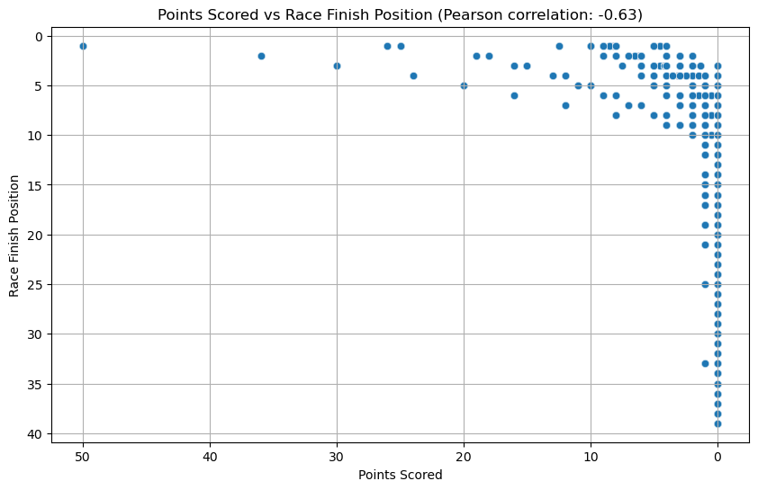

```
-0.627343086170116
```

```python
from scipy.stats import pearsonr

# Analyzing the correlation between points scored and race finishes

# We will use Pearson correlation to assess this relationship.
# However, we need to account for the fact that a lower position number is better in both qualifying and races.

# Calculating the Pearson correlation coefficient
correlation, _ = pearsonr(df['POINTS'], df['POSITIONORDER'])

# Plotting the relationship with correct column names
plt.figure(figsize=(10, 6))
sns.scatterplot(x='POINTS', y='POSITIONORDER', data=df, alpha=0.5)
plt.title(f'Points Scored vs Race Finish Position (Pearson correlation: {correlation:.2f})')
plt.xlabel('Points Scored')
plt.ylabel('Race Finish Position')
plt.gca().invert_xaxis()
plt.gca().invert_yaxis()
plt.grid(True)
plt.show()

correlation
```

#### Inference

This finding aligns with the scoring system used in Formula 1 where drivers receive points for finishing positions. The scatterplot clearly demonstrates this connection highlighting that higher points are generally associated with finishing positions (lower positionOrder values).

This analysis reinforces our understanding that in Formula 1 securing positions in races is crucial for earning points, which ultimately contributes to success in the championship standings.

```python
# Remove rows where 'POSITION' is "\N"
df = df[df['POSITION'] != '\\N'] # \N denotes to do not finish race, so we will slice the dataframe and pick only required records.

# converting datatype
df['POSITION'] = df['POSITION'].astype(int)
```

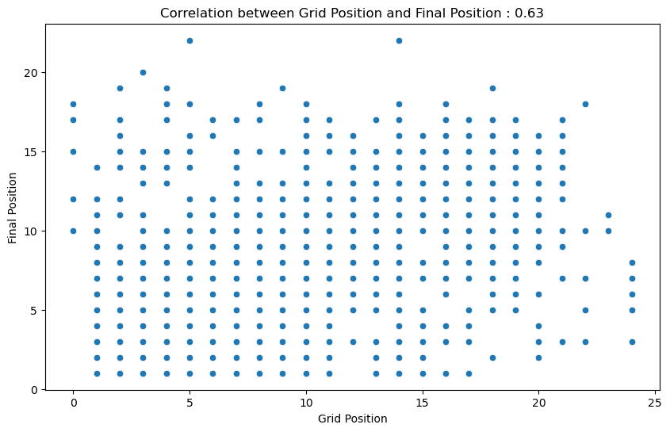

```python
#'DRIVER_NAME' is the column with driver names and 'WINS' is the column with their total wins

# we will make a new dataframe which has top 10 drivers data and their wins
top_10_drivers = df.groupby('DRIVER_NAME')['WINS'].sum().nlargest(10).index

# filtering the dataframe for only the top 10 drivers
top_10_df = df[df['DRIVER_NAME'].isin(top_10_drivers)]

# creating graph
plt.figure(figsize=(10, 6))
sns.scatterplot(x='GRID', y='POSITION', data=top_10_df)
correlation_coefficient = top_10_df['GRID'].corr(top_10_df['POSITION'])
plt.title(f'Correlation between Grid Position and Final Position : {correlation_coefficient:.2f}')
plt.xlabel('Grid Position')
plt.ylabel('Final Position')
plt.show()
```

#### Inference

The data suggests that there is a correlation (0.63) between grid position and final placement in races. In terms drivers who start closer to the front tend to finish in positions. However, it's important to note that there is some variability in the outcomes indicating that grid position alone does not solely determine the outcome. Other factors such as driver skill, team strategy, car performance, and incidents during the race also play roles. It's worth mentioning that some drivers consistently perform well when starting at the positions, which suggests they have a level of consistency in their performance or have teams supporting them. Overall, this graph indicates that while starting position is important, it's not the factor determining race outcomes as there is room for movement and changes throughout the race.

```python
# Points data for top 10 drivers
points_data = df.groupby('DRIVER_NAME')['POINTS'].sum().reset_index().sort_values('POINTS', ascending=False).head(10)
points_data
```

|  | DRIVER_NAME | POINTS |
| --- | --- | --- |
| 384 | Lewis Hamilton | 1462041.0 |
| 577 | Sebastian Vettel | 926302.0 |
| 180 | Fernando Alonso | 819516.0 |
| 371 | Kimi Räikkönen | 661169.0 |
| 428 | Michael Schumacher | 490158.0 |
| 424 | Max Verstappen | 398212.5 |
| 300 | Jenson Button | 396435.0 |
| 629 | Valtteri Bottas | 379779.0 |
| 580 | Sergio Pérez | 341611.0 |
| 456 | Nico Rosberg | 328467.0 |

```python
#Top 3 constructors
nation_points = df.groupby('CONSTRUCTORREF')['POINTS'].sum().reset_index().sort_values('POINTS', ascending=False).head(3)
nation_points
```

|  | CONSTRUCTORREF | POINTS |
| --- | --- | --- |
| 46 | ferrari | 2489549.30 |
| 102 | mercedes | 1865528.38 |
| 122 | red_bull | 1503756.50 |

#### Inference

Drivers and their team :

1. Lewis Hamilton - Mercedes
2. Sebastian Vettel - Ferrari
3. Fernando Alonso - Red Bull

The success of Formula 1 drivers is influenced by factors with their teams performance playing a role. Mercedes, Ferrari, and Red Bull are the leading teams in the sport, and their dominance can be attributed to aspects such as budgets, advanced technology, and their ability to attract top notch driving talent. This superiority is evident in the achievements of their drivers who frequently occupy positions in the standings.

Lets explore how the teams performance contributes to the success of their drivers particularly focusing on the three racers associated with Mercedes, Ferrari and Red Bull; These three teams possess resources to invest in research and development, resulting in cars that often possess a competitive advantage over other competitors. Whether it's engine power, aerodynamics, or other technological advancements, these teams strive for excellence.

### Visualization 2

#### Analysis for Average lap times for each circuit over the years

In our analysis we dive into the changes in lap times for Formula 1 circuits from 2004 and the current season of 2023. Our goal is to uncover insights about how technology, regulations, and drivers skills have shaped the sport over time. This examination goes beyond statistics by exploring the stories that have influenced the nature of Formula 1. Through this analysis we gain an understanding of the sports development and its ongoing commitment to achieving greatness on the racing tracks.

```python
# finding the count of each grand prix in dataframe
grand_prix = df['GRAND_PRIX'].value_counts().head(10)

# top 10 records
print("Top 10 Grand Prix with the most races:")
print(grand_prix)
```

```
Top 10 Grand Prix with the most races:
British Grand Prix      144575
Italian Grand Prix      138114
Belgian Grand Prix      125603
Monaco Grand Prix       122465
Spanish Grand Prix      119933
German Grand Prix       116486
French Grand Prix       115580
Brazilian Grand Prix    112240
Canadian Grand Prix     111569
Hungarian Grand Prix    103012
Name: GRAND_PRIX, dtype: int64
```

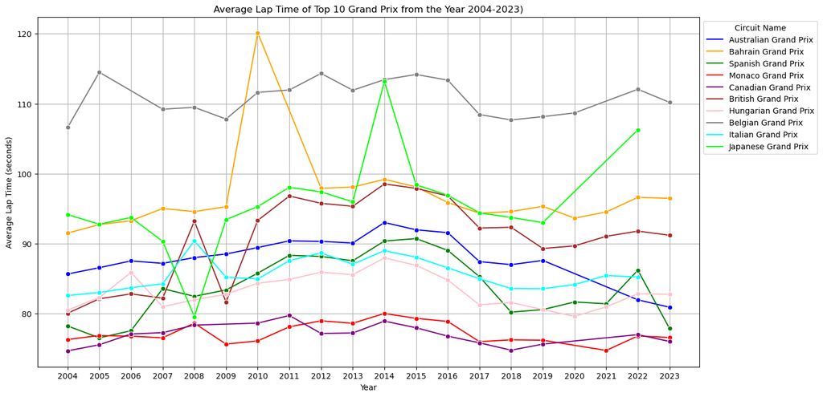

```python
# List of top 15 Grand Prix
grand_prix_list = [
    'Hungarian Grand Prix',
    'Spanish Grand Prix',
    'British Grand Prix',
    'Italian Grand Prix',
    'Monaco Grand Prix',
    'Bahrain Grand Prix',
    'Japanese Grand Prix',
    'Australian Grand Prix',
    'Canadian Grand Prix',
    'Belgian Grand Prix'
]

# List of colors to plot graph
color_list = ['blue', 'orange', 'green', 'red', 'purple', 'brown', 'pink', 'gray', 'cyan', 'lime']

# Filtering data for top 10 Grand Prix
df_filtered = df[df['GRAND_PRIX'].isin(grand_prix_list)]

# replacing \N (DNF) records
df_filtered = df_filtered.copy()
df_filtered['FASTESTLAPTIME'] = df_filtered['FASTESTLAPTIME'].replace(r'^\\N$', pd.NaT, regex=True)

# Droping Null records
df_filtered = df_filtered.dropna(subset=['FASTESTLAPTIME'])

# Converting into datetime format
df_filtered['FASTESTLAPTIME'] = pd.to_datetime(df_filtered['FASTESTLAPTIME'], format='%M:%S.%f')

# Extract minute and second information from 'FASTESTLAPTIME'
df_filtered['FASTEST_MINUTE'] = df_filtered['FASTESTLAPTIME'].dt.minute
df_filtered['FASTEST_SECOND'] = df_filtered['FASTESTLAPTIME'].dt.second + df_filtered['FASTESTLAPTIME'].dt.microsecond / 1e6

# Group by 'YEAR', 'CIRCUITID', and calculate average lap time
average_lap_time = df_filtered.groupby(['YEAR', 'CIRCUITID'])[['FASTEST_MINUTE', 'FASTEST_SECOND']].mean().reset_index()

# creating a new column for total time in seconds for better visualization
average_lap_time['AVERAGE_LAP_TIME_SECONDS'] = average_lap_time['FASTEST_MINUTE'] * 60 + average_lap_time['FASTEST_SECOND']


circuit_names = df_filtered.groupby('CIRCUITID')['GRAND_PRIX'].first().reset_index()

# merging with average_lap_time to include circuit names
average_lap_time = pd.merge(average_lap_time, circuit_names, on='CIRCUITID')

# Plotting the graph
plt.figure(figsize=(15, 8))


sns.lineplot(data=average_lap_time, x='YEAR', y='AVERAGE_LAP_TIME_SECONDS', hue='GRAND_PRIX', marker='o', palette=color_list)
plt.title('Average Lap Time of Top 10 Grand Prix from the Year 2004-2023)')
plt.xlabel('Year')
plt.ylabel('Average Lap Time (seconds)')
plt.xticks(range(int(average_lap_time['YEAR'].min()), int(average_lap_time['YEAR'].max())+1))



plt.legend(title='Circuit Name', loc='upper left', bbox_to_anchor=(1, 1))
plt.grid(True)
plt.show()
```

#### Inference

In 2010 there was a regulation implemented that prohibited refueling during races. This rule change resulted in the requirement for cars to have fuel tanks. Then in 2011 lap times were further extended due to the introduction of the DRS (Drag Reduction System). This system purposely increases drag on car spoilers. While it did slow down the cars, it added excitement as drivers had the ability to open the wing and reduce drag at moments during the race giving them a speed boost. Noticeable decreases in lap times have been observed since 2014 when V6 hybrid power units were introduced. Additionally in 2022, budget caps were imposed on teams along with restrictions on car designs that include wheel sizes and limitations, on certain aerodynamic features.

**3. Elements Affecting Variations in Lap Times**: Design changes have historically led to advancements in engineering, aerodynamics, and mid-engine configuration. Lap time trend changes could be explained by the recent emphasis on competitive racing above absolute speed.

[Improvement over the year](https://www.carscoops.com/2021/09/heres-how-formula-1-lap-times-have-improved-over-the-years/)

### Visualiazation 3

#### Crash Analysis and dangerous circuit analysis

1. **Analyzing Crashes** - Our objective is to examine data on F1 crashes with the aim of identifying recurring trends, determining causes, and recognizing patterns related to racing incidents. This analysis will offer insights into the consequences of crashes on drivers, teams, and the sport as a whole.
2. **Evaluation of Hazardous Circuits** - We will evaluate the safety measures and risk factors associated with racing circuits. Our focus will be on exploring circuits that have a frequency of crashes.

```python
# Most Dangerous Circuits
# Merging race data with results and status
results_with_status = pd.merge(results_df, status_df, on='statusId')
races_results_status = pd.merge(results_with_status, races_df, on='raceId')

# Filtering for accidents and collisions using keywords which we have in status dataframe
crash_data = races_results_status[races_results_status['status'].isin(['Accident', 'Collision', 'Damage','Injury','Collision damage'])]

# Counting crashes by circuit
circuit_crash_counts = crash_data.groupby(['circuitId', 'name']).size().reset_index(name='crash_count')
circuit_crash_counts = circuit_crash_counts.sort_values(by='crash_count', ascending=False)
circuit_crash_counts.head()
```

|  | circuitId | name | crash_count |
| --- | --- | --- | --- |
| 6 | 6 | Monaco Grand Prix | 197 |
| 13 | 13 | Belgian Grand Prix | 106 |
| 14 | 14 | Italian Grand Prix | 96 |
| 7 | 7 | Canadian Grand Prix | 88 |
| 9 | 9 | British Grand Prix | 84 |

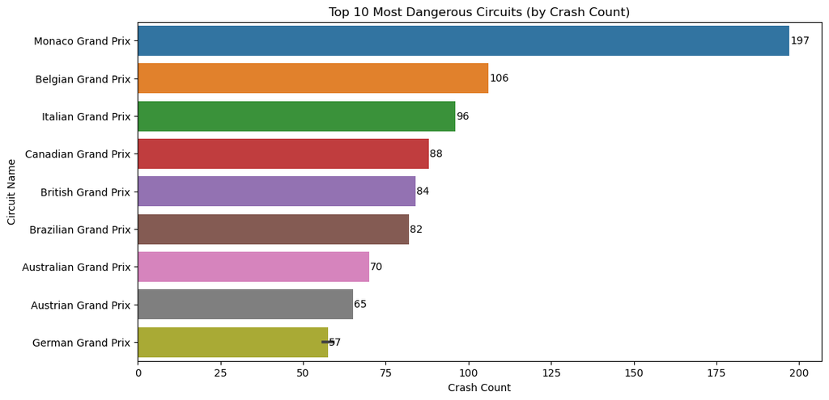

```python
# Creating a barplot
plt.figure(figsize=(12, 6))
barplot = sns.barplot(x='crash_count', y='name', data=circuit_crash_counts.head(10))

# Adding annotations for crash count on each bar
for p in barplot.patches:
    width = p.get_width()
    plt.text(width + 0.3, p.get_y() + p.get_height() / 2, f'{int(width)}', va='center')

# Setting plot title and labels
plt.title('Top 10 Most Dangerous Circuits (by Crash Count)')
plt.xlabel('Crash Count')
plt.ylabel('Circuit Name')
plt.show()
```

#### Formula 1 Circuit Safety Analysis

##### **Top 5 Most Dangerous Grand Prix in F1:**

Monaco Grand Prix -

- The streets of Monaco are infamous for their layout, tight corners and close barriers making it a dangerous circuit. The challenging track conditions are often blamed for the crashes that occur here.

Belgian Grand Prix -

- Spa Francorchamps is renowned as one of the circuits. Its combination of straights and demanding turns – the iconic Eau Rouge – contribute to high speed incidents.

Italian Grand Prix -

- Monzas high speed nature, coupled with braking zones frequently results in collisions. The circuits design featuring straights followed by chicanes pushes both car performance and driver skill to their limits.

Canadian Grand Prix -

- The Circuit Gilles Villeneuve gained its fame through the "Wall of Champions" where numerous legendary drivers have crashed. The tracks rapid transitions from high to low speeds heighten the risk of errors.

British Grand Prix -

- Silverstones fast corners like Maggots and Becketts test cars aerodynamic capabilities to the maximum. Mistakes at these speeds can lead to crashes.

##### **What Makes These Circuits Dangerous?**

Challenging Layouts and High Speeds -

- Circuits that have designs featuring corners, elevation changes, and sudden braking zones pose significant difficulties for drivers and increase the chances of accidents.

Narrow. Limited Safety Areas -

- Street circuits like Monaco and Albert Park are particularly hazardous due to their tracks and limited space for drivers to recover from any mistakes they make.

Unpredictable Weather Conditions -

- Tracks such as Spa and Interlagos often experience weather patterns which can rapidly alter track conditions and reduce tire grip ultimately leading to collisions.

Historical Significance -

- Some circuits have sections that have remained unchanged over the years due to their status even as cars have become faster and more demanding to handle. These sections can still pose risks to drivers.

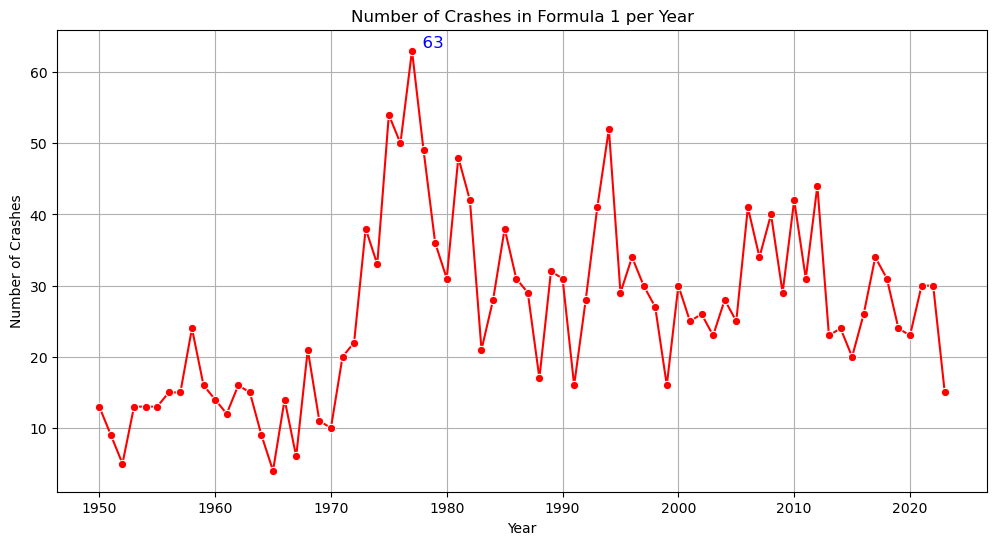

```python
# Creating a plot to visualize crash trends over the years
crash_counts = crash_data.groupby(['year']).size()
crash_counts = crash_counts.sort_values(ascending=False)
plt.figure(figsize=(12, 6))
sns.lineplot(x=crash_counts.index, y=crash_counts.values, marker='o', color='red')
plt.title('Number of Crashes in Formula 1 per Year')
plt.xlabel('Year')
plt.ylabel('Number of Crashes')
plt.grid(True)
for year, count in crash_counts.items():
    if count == crash_counts.max():
        plt.text(year, count, f'  {count}', color='blue', va='bottom', fontsize=12)
plt.show()
```

#### Analysis of Formula 1 Crashes (1950-2023)

This analysis delves into the evolution of Formula 1 crashes since its inception, in 1950 until 2023, shedding light on incidents.

##### **Historical Overview of F1 Crashes:**

The early years of Formula 1, from 1950 to the 1970s, were characterized by a level of risk compared to the day. This was mainly due to the safety protocols and basic technology at that time. Crashes during races often resulted in injuries or even fatalities.

However as the sport progressed into the 1960s and 1970s, significant technological advancements took place. These included the introduction of aerodynamics and turbocharged engines which increased speeds, but also raised concerns about the risk of crashes.

One notable year for crashes was in 1977 with 63 crashes in total. During this period there was a peak in accidents due to factors of rapid technological innovations, competition among teams and drivers, evolving regulations, and insufficient safety measures all contributed to this increase in incidents. [F1 Fatalities](https://en.wikipedia.org/wiki/List_of_Formula_One_fatalities)

##### **Impactful Incidents and Their Consequences:**

The unfortunate incident involving **Ayrton Senna** during the San Marino Grand Prix in 1994 marked a moment for Formula 1. Sennas tragic death prompted a renewed emphasis on safety measures resulting in changes such as enhanced crash barriers redesigned tracks and the implementation of the HANS (Head and Neck Support) device to safeguard drivers against head and neck injuries.

Another significant occurrence was **Jules Bianchis** accident at the Japanese Grand Prix, in 2014. This incident took place under conditions involved a recovery vehicle leading to the implementation of the Virtual Safety Car (VSC) system and stricter regulations regarding race conduct when faced with adverse weather conditions.

##### **Evolution of Safety Measures:**

Post the safety reforms that occurred after 1994; After the death of Senna there was a revamping of safety standards. The FIA implemented regulations for both cars and circuits resulting in the development of car designs enhanced helmets and improved track safety features. [F1 Safety Devices](https://f1chronicle.com/the-history-of-formula-1-safety-devices/)

Innovations in the century; Throughout the 2000s and 2010s there were advancements in ensuring safety. These included the utilization of materials for constructing cars, real time monitoring of car conditions through telemetry and the introduction of the Halo cockpit protection system, in 2018. [Innovations](https://www.sportskeeda.com/f1/how-safety-evolved-through-the-years-in-formula-one)

##### **Recent Trends (2000-2023):**

Decrease in Fatalities:

- Due to continuous improvements in safety standards.

#### Circuit and Safety Analysis Conclusion

The mix of paced racing, track layouts, and unforeseeable factors like weather conditions makes these circuits especially risky. Although safety advancements in times have considerably decreased the occurrence of accidents in Formula 1, the essential peril of these circuits still pushes drivers capabilities and car performance to their limits.

#### Visualiazation 4

#### Analysis for Driver Nationality

Formula 1, with its range of drivers from over the world presents an intriguing stage where competitors from different nationalities strive for success. It's natural to ponder about the variations in wins, finishing positions, and how the number of drivers relates to their triumphs. Let's delve into an analysis that uncovers the relationship between nationality and performance metrics in the captivating realm of Formula 1.

```python
# Determining the number of drivers for each nationality
nationality_driver_counts = drivers_df['nationality'].value_counts().reset_index()
nationality_driver_counts.columns = ['nationality', 'drivers']

# combining driver standings data with driver's data
nationality_df = pd.merge(driver_standings_df, drivers_df, on='driverId')

# checking the number of wins of each driver
driver_win_df = nationality_df.loc[nationality_df.groupby('driverId')['wins'].idxmax()]

# checking the total number of wins for each nationality
nationality_wins_counts = nationality_df.groupby('nationality')['wins'].sum()

# checking the mean finishing position for each nationality
nationality_position = nationality_df.groupby('nationality')['position'].mean().reset_index()
nationality_position.columns = ['nationality', 'mean_position']

# combining results counts of drivers, total wins, win-to-driver ratio, and mean position
combined_df = pd.merge(nationality_driver_counts, nationality_wins_counts, on='nationality', how='outer')
combined_df['win_driver_ratio'] = combined_df['wins'] / combined_df['drivers']
combined_df = pd.merge(combined_df, nationality_position, on='nationality', how='outer')

# Replace NaN values with 0
combined_df = combined_df.fillna(0)

# Organize nationality by total wins and mean position
combined_df = combined_df.sort_values(by=['wins', 'mean_position'], ascending=[False, True]).reset_index(drop=True)

combined_df
```

|  | nationality | drivers | wins | win_driver_ratio | mean_position |
| --- | --- | --- | --- | --- | --- |
| 0 | British | 165 | 2508 | 15.200000 | 19.762084 |
| 1 | German | 50 | 1746 | 34.920000 | 15.001470 |
| 2 | Brazilian | 32 | 853 | 26.656250 | 13.137179 |
| 3 | French | 73 | 730 | 10.000000 | 17.270851 |
| 4 | Finnish | 9 | 495 | 55.000000 | 10.192373 |
| 5 | Dutch | 18 | 419 | 23.277778 | 19.151563 |
| 6 | Spanish | 15 | 359 | 23.933333 | 15.304829 |
| 7 | Australian | 18 | 335 | 18.611111 | 15.476091 |
| 8 | Austrian | 15 | 310 | 20.666667 | 13.553939 |
| 9 | Italian | 99 | 281 | 2.838384 | 19.987461 |
| 10 | Argentine | 24 | 226 | 9.416667 | 21.932813 |
| 11 | American | 158 | 225 | 1.424051 | 37.018191 |
| 12 | Canadian | 14 | 139 | 9.928571 | 14.937374 |
| 13 | South African | 23 | 90 | 3.913043 | 25.922185 |
| 14 | New Zealander | 9 | 86 | 9.555556 | 13.552894 |
| 15 | Mexican | 6 | 82 | 13.666667 | 13.107527 |
| 16 | Swedish | 10 | 77 | 7.700000 | 18.870918 |
| 17 | Monegasque | 4 | 71 | 17.750000 | 19.958549 |
| 18 | Belgian | 23 | 56 | 2.434783 | 22.799076 |
| 19 | Swiss | 23 | 42 | 1.826087 | 19.436620 |
| 20 | Colombian | 3 | 36 | 12.000000 | 13.308219 |
| 21 | Venezuelan | 3 | 16 | 5.333333 | 21.116788 |
| 22 | Polish | 1 | 12 | 12.000000 | 12.104762 |
| 23 | Russian | 4 | 0 | 0.000000 | 14.940367 |
| 24 | Thai | 2 | 0 | 0.000000 | 15.735294 |
| 25 | Chinese | 1 | 0 | 0.000000 | 16.382353 |
| 26 | Danish | 5 | 0 | 0.000000 | 16.596567 |
| 27 | Malaysian | 1 | 0 | 0.000000 | 17.277778 |
| 28 | Japanese | 20 | 0 | 0.000000 | 18.905248 |
| 29 | Hungarian | 1 | 0 | 0.000000 | 19.400000 |
| 30 | Indian | 2 | 0 | 0.000000 | 22.162791 |
| 31 | Indonesian | 1 | 0 | 0.000000 | 22.809524 |
| 32 | Chilean | 1 | 0 | 0.000000 | 23.456522 |
| 33 | Czech | 1 | 0 | 0.000000 | 24.000000 |
| 34 | Irish | 5 | 0 | 0.000000 | 24.576271 |
| 35 | Rhodesian | 4 | 0 | 0.000000 | 25.021277 |
| 36 | Portuguese | 4 | 0 | 0.000000 | 25.081818 |
| 37 | Argentine-Italian | 1 | 0 | 0.000000 | 28.777778 |
| 38 | Liechtensteiner | 1 | 0 | 0.000000 | 28.850000 |
| 39 | Uruguayan | 4 | 0 | 0.000000 | 39.333333 |
| 40 | American-Italian | 1 | 0 | 0.000000 | 67.500000 |
| 41 | East German | 3 | 0 | 0.000000 | 68.600000 |

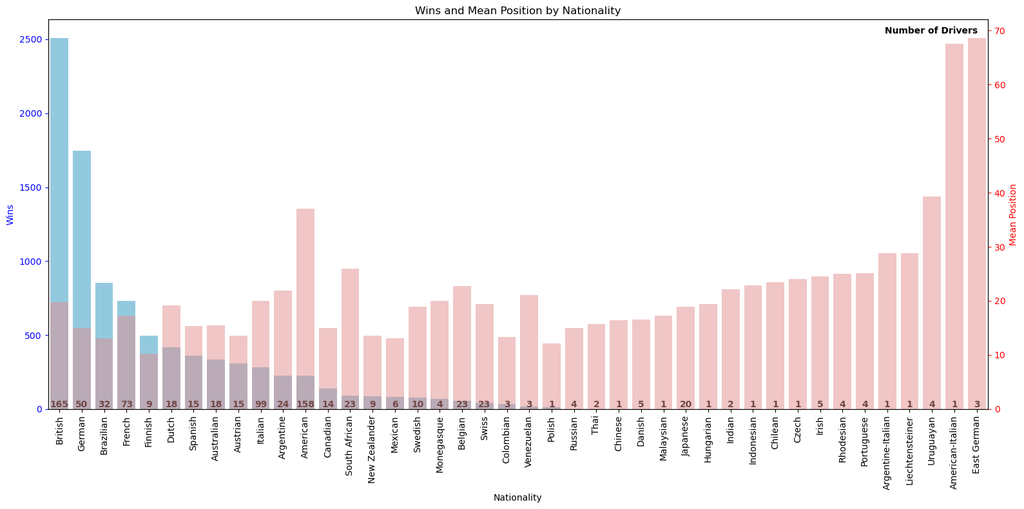

```python
fig, ax1 = plt.subplots(figsize=(16, 8))

# Bar plot for number of wins by nationality
sns.barplot(x='nationality', y='wins', data=combined_df, color='skyblue', ax=ax1)
ax1.set_title('Wins and Mean Position by Nationality')
ax1.set_xlabel('Nationality')
ax1.set_ylabel('Wins', color='blue')
ax1.tick_params('y', colors='blue')
ax1.set_xticklabels(combined_df['nationality'], rotation=90)

# twin Axes sharing the x-axis
ax2 = ax1.twinx()

# Bar plot for Mean Position
sns.barplot(x='nationality', y='mean_position', data=combined_df, color='lightcoral', ax=ax2, alpha=0.5)

#label and tick parameters for the mean positions
ax2.set_ylabel('Mean Position', color='red')
ax2.tick_params('y', colors='red')

#labels for the number of drivers
for i, bar in enumerate(ax1.patches):
    ax1.text(
        bar.get_x() + bar.get_width() / 2,
        0,
        f"{combined_df['drivers'].iloc[i]:.0f}",
        ha='center',
        va='bottom',
        color='black',
        fontweight='bold'
    )

# Text annotation on the number of drivers
ax1.text(
    .94,
    .97,
    'Number of Drivers',
    ha='center',
    va='center',
    transform=ax1.transAxes,
    color='black',
    fontweight='bold'
)

plt.tight_layout()
plt.show()
```

#### Inference

This analysis explores the correlation between a driver's nationality and their success in Formula 1, revealing insights across different performance metrics. By examining total wins and average finishing positions associated with different nationalities, the study unveils patterns that shed light on the nuanced dynamics of success in the sport.

**Number of Wins**:

The bar chart displaying total wins by nationality is organized in a logical sequence from most to least wins in blue. It shows a significant drop after the top nations, indicating a vast difference in wins between the top performers and the remainder.

- Top Performers: British drivers top the pack with 2508 victories, demonstrating their dominance in the sport. German drivers come in second with 1746 victories, demonstrating a significant presence.
- Other strong contenders: Brazilian, French, Finnish, and Dutch drivers, with 400+ wins, reflect their countries' strong performances.
- Moderate Achievers: Drivers from Spain, Australia, and Austria are in the middle tier, with victories in the 300s. They may not be the dominant force but have a notable impact.
- Gaining Momentum: Nations like Colombia, Venezuela, and Poland show fewer victories, indicating less success but evolving participation.
- Yet to Make a Mark: Russian, Thai, and Chinese drivers have no wins, showing a limited representation and lack of success in the sport.

**Average Finishing Positions**:

**Insights into Success Factors of Nations**:

Comparing between two nationalities with the most drivers, British and American, British had an overwhelming number of wins with 165 drivers, but American had a significant smaller number of wins with 158 drivers, demonstrating more drivers does not yield more wins. Moreover, Finland with just 9 drivers had obtained a notable number of victories.

- There are a couple reasons as to why Formula 1 saw the most British Drivers and champions. Those can be attributed at a combination of historical and cultural factors. First, there is a rich history in motorsports in the UK, and Formula 1 originated in Europe, with the [first official World Championship race](https://www.silverstone.co.uk/about/history-grand-prix) held at Silverstone, UK, in 1950. The early establishment of Formula 1 and the historical legacy in the UK contributed to the development of a strong motorsport tradition and fostered a culture of motorsport enthusiasts and aspiring racers. In addition to this, the culture has driven continuous investment, sponsorship, resources, and offerings of comprehensive motorsport education and training for talented drivers to develop and advance to a higher level. Moreover, London, in particular, serves as a global hub for motorsport business and management, with many Formula 1 teams basing their headquarters in the UK, thus attracting more talent from around the world.
- Similarly with German and Brazil, and those top ranked nations, they have deep-rooted culture in motorsport and a strong passion for the sport. Those have facilitated significant investment and support for the development of young talents, as well as other technical advancements involving motorsports.
- [Finland](https://www.sema.org/news-media/magazine/2021/03/land-sisu) also has a lively racing culture, with a strong tradition of karting. The emphasis on karting in addition to the challenging winter conditions in Finland, including ice and snow, contribute to exceptional car control skills, which is particularly advantageous in Formula 1.

**Overall Conclusion on Nationality's Role**:

While nationality does not directly affect wins, a nation's culture, support, and environment significantly influence driver achievements in Formula 1. It is worth noting that the performance of top nations is influenced by a combination of historical legacy, cultural passion, and investment.

## Conclusion

Our comprehensive exploration of Formula 1 dynamics has yielded invaluable insights that hold practical implications for the sport's stakeholders. Formula 1's legacy is not merely a result of speed and precision but is shaped by the intricate interplay of technological advancements, diverse track challenges, and the cultural tradition that defines the sport.

**Performance Drivers:** Success in Formula 1 boils down to the collaboration between drivers and teams. Our analysis highlights that starting position and points earned are pivotal factors influencing final race outcomes. This correlation emphasizes the need for a delicate balance between individual driver skill and cohesive team performance.

**Safety and Circuit Challenges:** Significant milestones in safety measures post-1994 have led to a notable reduction in fatalities. However, identifying circuits with distinctive challenges, such as Monaco and Spa-Francorchamps, underscores the ongoing importance of driver skills. The emphasis on safety remains paramount for sustained success.

**Nationality and Success Patterns:** While nationality itself doesn't determine victories, the success of top-performing nations like the UK, Germany, and Brazil suggests the profound impact of cultural, historical, and investment factors on driver achievements. Understanding these influences provides a strategic edge in talent development.

**Strategic Implications:** Strategically, these findings offer clear guidelines for decision-makers in the world of Formula 1. Teams should focus on strategies that maximize points, aligning with the strong correlation between points and championship success. Additionally, recognizing circuit-specific challenges is essential; adapting car designs and strategies to suit the unique characteristics of each track can be a differentiating factor. Continuous commitment to safety measures, leveraging evolving technologies, is not only a moral imperative but a strategic necessity in mitigating risks and ensuring sustained success.

In essence, this synthesis of insights serves as a roadmap for strategic decision-making in Formula 1, providing stakeholders with a clear understanding of the dynamics that drive success in this highly competitive and dynamic sport.

## References

1. https://www.kaggle.com/datasets/rohanrao/formula-1-world-championship-1950-2020/data?select=circuits.csv
2. https://www.carscoops.com/2021/09/heres-how-formula-1-lap-times-have-improved-over-the-years/
3. https://en.wikipedia.org/wiki/List_of_Formula_One_fatalities
4. https://f1chronicle.com/the-history-of-formula-1-safety-devices/
5. https://www.sportskeeda.com/f1/how-safety-evolved-through-the-years-in-formula-one
6. https://www.silverstone.co.uk/about/history-grand-prix
7. https://www.sema.org/news-media/magazine/2021/03/land-sisu

[figure not shown]